# **Modelación de sistemas dinámicos**

# ODE de segundo orden

### M. en C. Jonathan A. Urrutia Anguiano

### MA1035.535

## ODE de segundo orden

$$ \mdv{y}{t}{2} = f\left(y,\dv{y}{t},t\right), $$

donde $y = y(t)$ es la función a determinar, $t$ su variable dependiente y $f$ una función que depende de $y$, $\dd y/\dd t$, así como de $t$

No es sorpresa que dar solucipon a una ODE de segundo orden es una tarea compliada y por lo mismo, el conjunto de ODE de seguno orden que podemos resolver es menos al de ODE de primer orden.

La idea para abordar **ODE de segundo orden** consiste en proponer soluciones de tal forma que podamos usar resultado anteriores de ODE lineales o de álgebra básica. Para esto recordameros brevemete algunos conceptos de álgebra lineal.

## Concepto de álgebra

### Fórmula general de segundo grado (Chicharronera)

Si se tiene un polinomio de grado dos en $x$ y es igualado a cero, entonces se conoce la solución:

$$ a x^2 + b x + c = 0 \qquad\iff \qquad x = \frac{1}{2a}\left(-b \pm \sqrt{b^2 - 4 a c}\right) $$

Recordemos que dependiendo de los valores de los coeficientes $a$, $b$ y $c$, hay tres casos posibles

- $b^2 - 4 a c > 0$: hay dos soluciones reales para $x$
- $b^2 - 4 a c < 0$: hay dos soluciones complejas para $x$
- $b^2 - 4 a c = 0$: hay una sola solución real

## Independencia lineal

Un conjunto de funciones $\{y_i(t)\}$ el **linealmente dependiente** si $$ a_1 y_1(t) + a_2 y_2(t) + \ldots + a_n y_n(t) = 0\qquad\text{para valores de $a_i$ distindos de cero simultáneamente.} $$ De forma análoga, el conjunto con funciones $\{y_i(t)\}$ es **linealmente independiente (l.i)** si $$ a_1 y_1(t) + a_2 y_2(t) + \ldots + a_n y_n(t) = 0\qquad\text{sólo si todos los $a_i$ son iguales a cero.} $$

Es importante notar que para una ODE de orden $n$, debemos tener $n$ funciones linealmenteindependientes.

Una forma de determinar que el conjunto de funciones es l.i es definiendo la función **Wronskiano**

### El wronskiano

En particular podemos ver el caso cuando tenemos dos funciones $y_1(t)$ y $y_2(t)$. Para ver si son linealmente independientes podemos planetar el siguiente sistema de ecuaciones $$ \begin{aligned} a_1 y_1(t) + a_2 y_2(t) =& 0,\\ a_1 y_1^{(1)}(t) + a_2 y_2^{(1)}(t) =& 0,\\ \end{aligned} \qquad \Longrightarrow\qquad \left(\begin{array}{cc} y_1(t) & y_2(t) \\ y_1^{(1)}(t) & y_2^{(1)}(t) \end{array} \right) \left(\begin{array}{c} a_1 \\ a_2 \end{array}\right) =\left(\begin{array}{c} 0 \\ 0 \end{array} \right), \tag{1} $$ donde el número entre paréntesis indica que se realizó una primera derivada.

El Ec. (1) se cumple de forma inmediata para $a_1 = a_2 = 0$ pero esta es la solución trivial que no nos da información sobre las funcines. Si los coeficnentes $a_1$ y $a_2$ no sean cero, una forma de garantizar que la Ec. (1) siga cumplíendose es que el determinante de la matriz sea cero. Entondes definimos la función Woronskiano como

$$ W(t) = \text{det}\left|\begin{array}{cc} y_1(t) & y_2(t) \\ y_1^{(1)}(t) & y_2^{(1)}(t) \end{array} \right| = y_1(t)y_2^{(1)}(t) - y_2(t) y_1^{(1)}(t) = W[y_1,y_2](t). $$

Si $W(t)$ es cero, entonces se cumple la igualdad y por tanto $y_1$ y $y_2$ son linealmente dependientes, pero si no fuera cero entonces sólo existe la solución trivial,teniendo así que $y_1$ y $y_2$ son lindealmente independientes. En resumen

$$ W[y_1(t),y_2(t)] \neq 0 \qquad \Longrightarrow \qquad \text{ Las funciones $y_1(t)$ y $y_2(t)$ son linealmente independientes} $$

### Ejemplo:

Supongamos el conjunto de funciones $\{\exp(x),\,\exp(-x),\sinh(x)\}$. Para ver si este es un conjunto linealmente independiente tenemos que mostrar que el Wronkiano formado por esas funciones y sus dos primera derivadas es distinto de cero. $$ W[\exp(x),\exp(-x),\sinh(x)] = \det\left( \begin{array}{ccc} \exp(x) & \exp(-x) & \sinh(x)\\ \exp(x) & -\exp(-x) & \cosh(x)\\ \exp(x) & \exp(-x) & \sinh(x) \end{array} \right) $$ Las derivadas y propiedades de las funciones hiperbólicas las puedes consultar en [Wikipedia](https://en.wikipedia.org/wiki/Hyperbolic_functions) y puede que sea últil que recuerdes el cálculo de [determinantes de tres por tres](https://es.khanacademy.org/math/algebra-home/alg-matrices/alg-determinants-and-inverses-of-large-matrices/v/finding-the-determinant-of-a-3x3-matrix-method-2) ($3\times 3$). Esto da como resultado $$ \begin{aligned} W[\exp(x),\exp(-x),\sinh(x)] = & \exp(x) \det\left(\begin{array}{cc} -\exp(-x) & \cosh(x)\\ \exp(-x) & \sinh(x) \end{array}\right) - \exp(-x) \det\left(\begin{array}{cc} \exp(x) & \cosh(x)\\ \exp(x) & \sinh(x) \end{array}\right) \\ \\ & +\sinh(x) \det\left(\begin{array}{cc} \exp(x) & -\exp(-x) \\ \exp(x) & \exp(-x) \end{array}\right)\\ \\ =& -\sinh(x)-\cosh(x)-\sinh(x)+\cosh(x) +2\sinh(x) = 0 \end{aligned} $$ Entonces existe al meno una combinación lineal de esas funciones igual a a cero.

Por otro lado, para el caso de $\sin(x)$ y $\cos(x)$ se cumple lo siguiente $$ \begin{aligned} W[\sin(x),\cos(x)] = \det\left(\begin{array}{cc} \sin(x) & \cos(x)\\ \cos(x) & -\sin(x) \end{array}\right) = -\sin^2(x) - \cos^2(x) = -1 \end{aligned} $$ por lo que son funciones lineamente independientes.

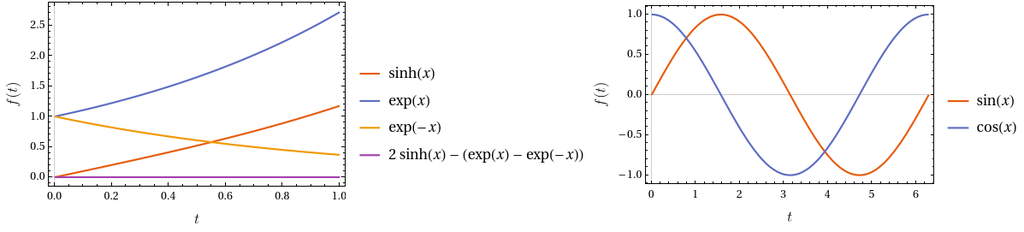

```python
Row[{Plot[{Sinh[x],Exp[x],Exp[-x], 2*Sinh[x]-  (Exp[x] -Exp[-x]) },{x,0,1},
PlotTheme -> "Scientific", FrameLabel -> frameft, FrameStyle -> Black,PlotLegends->"Expressions", ImageSize->300]
,
Plot[{Sin[x],Cos[x] },{x,0,2*Pi},
PlotTheme -> "Scientific", FrameLabel -> frameft, FrameStyle -> Black,PlotLegends->"Expressions", ImageSize->300]
}]
```

## ODE de segundo grado

Como se mencionó anteriormente estas ODE son más complicadas que las de primer orden sin embargo por lo mismo hay un número delimitado de técnicas para resolverlas y en muchos de los casos, se aborda el problemas al proponer una solución y ver qué condiciones deben de cumplir los parámetros de esta solución para que, en efecto, cumpla con nuestra ecuación diferencial.

En particular se abordarán los siguientes métodos:

- Polinomio característico (Para resolver la ecuación homogénea)
- Coeficientes indeterminados (Para resolver la ecuación no-homogénea)
- Reducción de orden (Conociendo una solución del caso homogéneo)
- Variación de parámetros (Determinar una solución al caso no-homogéneo, con el caso homogéneo resuelto)

## Polinomio característico

Consideremos el caso de una ODE lineal de segundo grado y en su formulación homogénea con **coeficientes constantes**, es decir $$ a y''(t) + b y'(t) + c y(t) = 0, \qquad\text{donde}\qquad y' = \dv{y}{t},\;y'' = \mdv{y}{t}{2} $$ En este caso propongamos una solución y al derivarla dos vece sustituyamos en la expresión anterior $$ \text{Prongamos:}\quad y(t) = \exp(\lambda t) \quad\Longrightarrow \quad y'(t) = \lambda \exp(\lambda t) \quad\Longrightarrow \quad y''(t) = \lambda^2 \exp(\lambda t) $$ Por lo tanto notemos que $$ y(t) = \exp(\lambda t) \quad\Longrightarrow \quad a y''(t) + b y'(t) + c y(t) = \exp(\lambda t)(a\lambda^2 + b \lambda + c) = 0 $$ y como $\exp(\lambda t)\neq 0$, entones basta con resolver las raíces del polinomio de grado dos de $\lambda$. Es decir **convertimos nuestra ecuación diferencial en una algebráica**, cuya solución es $$ \lambda = \frac{-b}{2a} \pm \frac{\sqrt{b^2-4ac}}{2a} \quad\Longrightarrow\quad y_\pm (t) = A_\pm\exp\left(\frac{-bt}{2a}\right)\exp\left(\pm\frac{\sqrt{b^2-4ac}}{2a}t\right) $$ donde $A_\pm$ son coeficientes que acompañan a las dos soluciones linealmente independientes

### Ejemplo de ODE de segundo orden con coeficientes constantes

Este tipo de ODE, aunque sea un caso simplificado, puede representar varias situaciones físicas. En particular, puede modelar la ecuación de movimiento de una partícula de masa $m$ sometida a un resorte con una fuerza de restitución proporcional a $m\omega^2$, con $\omega$ la frecuencia de resonancia del resorte, y sometida a la resistencia del aire según la ley de Stokes. En este caso, la segunda ley de Newton dica que la ecuación de movimiento es:

$$ m \mdv{x(t)}{t}{2} + m\gamma \dv{x(t)}{t} + m\omega^2 x(t) = 0 $$

Si te es de utilidad, te recomiendo [este recurso](https://beltoforion.de/en/harmonic_oscillator/#:~:text=The%20damped%20harmonic%20oscillator%20is,equation%20for%20the%20damped%20oscillator) donde se desarrolla toda la teoría con base en el polinomio caracterísitico.

### Supongamos: $b = 0$ y $(a \cdot c)>0$

Nuestra ecuación diferencial en este caso, así como su solución se rescribe como $$ a y''(t)+ c y(t) = 0, \quad\Longrightarrow\quad y_\pm (t) = A_\pm\exp\left(\pm\frac{\sqrt{-4ac}}{2a}t\right) = A_\pm\exp\left(\pm i\frac{\sqrt{4ac}}{2a}t\right) $$ y dado que las exponenciales complejas son una combinación lineal de senos y cosenos, nuestra solución general (de dos funciones l.i.) puede escribirse como $$ a y''(t)+ c y(t) = 0, \quad\Longrightarrow\quad y_\pm (t) = A_1\sin\left(\frac{\sqrt{4ac}}{2a}t\right) + A_2\cos\left(\frac{\sqrt{4ac}}{2a}t\right) $$

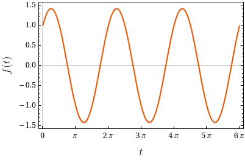

```python
Plot[Sin[t] + Cos[t],{t,0,6*Pi},
PlotTheme -> "Scientific", FrameLabel -> frameft, FrameStyle -> Black,PlotLegends->"Expressions", ImageSize->300,
FrameTicks -> {{Automatic,Automatic},{Table[i,{i,0,8*Pi,Pi}],Automatic}}]
```

### Supongamos: $b = 0$ y $(a\cdot c)<0$

Nuestra ecuación diferencial en este caso, así como su solución se rescribe como $$ a y''(t)+ c y(t) = 0, \quad\Longrightarrow\quad y_\pm (t) = A_\pm\exp\left(\pm\frac{\sqrt{-4ac}}{2a}t\right) $$ y en este caso el argumento de la raíz es positivo por lo que nuestrasolución puede escribirse como $$ a y''(t)+ c y(t) = 0, \quad\Longrightarrow\quad y_\pm (t) = A_+\exp\left(\frac{\sqrt{4ac}}{2a}t\right) + A_-\exp\left(-\frac{\sqrt{4ac}}{2a}t\right) $$ o de forma equivalente $$ a y''(t)+ c y(t) = 0, \quad\Longrightarrow\quad y_\pm (t) = A_1\sinh\left(\frac{\sqrt{4ac}}{2a}t\right) + A_2\cosh\left(\frac{\sqrt{4ac}}{2a}t\right) $$

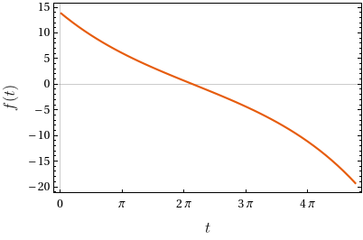

```python
Plot[-Exp[t/5] + 15*Exp[- t/ 5],{t,0,15},
PlotTheme -> "Scientific", FrameLabel -> frameft, FrameStyle -> Black,PlotLegends->"Expressions", ImageSize->300,
FrameTicks -> {{Automatic,Automatic},{Table[i,{i,0,8*Pi,Pi}],Automatic}}]
```

### Supongamos: $b \neq 0$ y $b^2-4ac \neq 0$

En este caso, las soluciones anteriores se acompañan por una **envolvente** que modula la solución y hace que decaiga (o aumente) conforme crece la variable $t$ $$ a y''(t) + b y'(t) + c y(t) = 0, \qquad\text{donde}\qquad \quad y_\pm (t) = A_\pm\exp\left(\frac{-bt}{2a}\right)\exp\left(\pm\frac{\sqrt{b^2-4ac}}{2a}t\right). $$

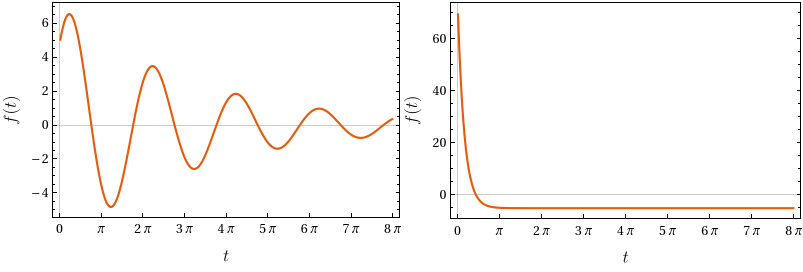

```python
Row[{
Plot[5*Exp[-t/10](Sin[t] + Cos[t]),{t,0,8*Pi},
PlotTheme -> "Scientific", FrameLabel -> frameft, FrameStyle -> Black,PlotLegends->"Expressions", ImageSize->300,PlotRange->All,
FrameTicks -> {{Automatic,Automatic},{Table[i,{i,0,8*Pi,Pi}],Automatic}}]
,
Plot[5*Exp[-t]*(-Exp[t] + 15*Exp[- t]),{t,0,8*Pi},
PlotTheme -> "Scientific", FrameLabel -> frameft, FrameStyle -> Black,PlotLegends->"Expressions", ImageSize->300,PlotRange->All,
FrameTicks -> {{Automatic,Automatic},{Table[i,{i,0,8*Pi,Pi}],Automatic}}]
}]
```

### Supongamos: $b \neq 0$ y $b^2-4ac = 0$

En este caso, mediante el método del polinomio caracterísiticolo sólo hay una solución, dada por $$ a y''(t) + b y'(t) + c y(t) = 0, \qquad\text{donde}\qquad \quad y_\pm (t) = A_1\exp\left(\frac{-bt}{2a}\right). $$

Para obtener otra función linealmente independiente que sea solución a la ODE, se emplea el **método de reducción de orden** para construirla (que se verá más adelante). Por el momento notemos que la solución general está dada por $$ a y''(t)+ by'(t) + c y(t) = 0, \quad\Longrightarrow\quad y_\pm (t) = \left(A_1 + A_2 t\right)\exp\left(\frac{-bt}{2a}\right) $$

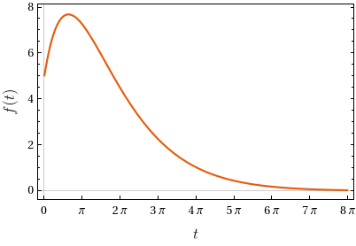

```python
Plot[5*Exp[-t/3](1+t),{t,0,8*Pi},
PlotTheme -> "Scientific", FrameLabel -> frameft, FrameStyle -> Black,PlotLegends->"Expressions", ImageSize->300,PlotRange->All,
FrameTicks -> {{Automatic,Automatic},{Table[i,{i,0,8*Pi,Pi}],Automatic}}]
```

## Coeficientes indeterminados

Consideremos el caso de una ODE lineal de segundo grado y en su formulación no homogénea con **coeficientes constantes**, es decir $$ y''(t) + p y'(t) + q y(t) = f(t), \qquad\text{donde}\qquad y' = \dv{y}{t},\;y'' = \mdv{y}{t}{2} $$ La solución al caso homogéneo ($f(t) = 0$) ya se ha abordado. Lo que resta para tener la solución completa a esta ecuación es calcular la solución particular del caso no homogéneo. La idea básica de este método es el **proponer una solución educada** con base en la forma de $f(t)$. Es decir, si $f(t)$ es una función sinoidal, exponencial, o una potencial, debemos **proponer una combinación con las funciones que conforman a $\mathbf{f(t)}$**, y determinar los coeficientes de la combinación lineal.

### Método:

- Analizar $f(t)$ e identificarla en términos de funciones *elemetales*
- Porponer una combinación lineal con coeficientes constantes
- Sustituir la combinación en la ODE
- Resolver para los coeficientes

Puedes revisar teoría y ejemplos en [este portal](https://tutorial.math.lamar.edu/classes/de/undeterminedcoefficients.aspx)

### Propuestas de soluciones

| $f(t)$ | Popuesta de solución |
| --- | --- |
| $\exp(\alpha t)$ | $a_\alpha \exp(\alpha t)$ |
| $\cos(\beta t)$ | $a_\beta \sin(\beta t) + a_\beta \cos(\beta t)$ |
| $\sin(\gamma t)$ | $a_\gamma \sin(\beta t) + a_\gamma \cos(\gamma t)$ |
| Polinomio de grado $m$ | $a_m t^m + a_{m-1}t^{m-1} + \ldots + a_1 t + a_0$ |
| $t\exp(\eta t)$ | $\exp(\eta t)(a_1 + a_2 t)$ |

## Ejemplo:

Supongamos que nuestra ODE a resolver es: $$ y'' - 4 y' - 12y = 3 \exp(5 t) $$

Para resolver el caso homogéneo empleamos el método de la ecuación característica, dando como resultado que si $y_h(t) = \exp(\lambda t)$ entonces $$ y'' - 4 y' - 10 y = \exp(\lambda t)\left( \lambda^2 - 4 \lambda + 12\right) = 0\qquad\Longrightarrow\qquad \lambda_1 = -2,\,\lambda_2 = 6 $$ Por lo tanto, para determinar la solución particular $y_p(t)$, proponemos $y_p(t) = a \exp(5 t)$,por lo que $$ y_p(t) = a \exp(5 t)\quad\Longrightarrow\quad y_p'(t) = 5a\exp(5t)\quad\Longrightarrow\quad y_p'''(t) = 25a\exp(5t) $$ y sustituimos en la ODE: $$ y'' - 4 y' - 12y = \exp(5t) \left(25 a - 4(5a) + 12a \right) = -7a \exp(5t) = 3 \exp(5t), $$ por lo que $a = -3/7$. Es decir la solución a la ODE es: $$ y(t) = y_h(t) + y_p(t) = a_1 \exp(-2 t) + a_2 \exp(6 t) - \frac37\exp(5 t) $$

## Reducción de orden:

### Ecuación sin dependencia explícita en $y(t)$

Para el caso genderal de una ODE de segundo orden, se propone el cambio de variable $z(t) = \dd y/\dd t$, lo que reducirá la expresión a una ODE de primer orden, sin emabrgo esto no garantiza que haya una solución general. Cuando esto sí es posible es en el caso de ODE lineles sin una dependencia explícita en $y(t)$, es decir

$$ a(t)y''(t) + b(t) y'(t) = f(t) \quad \Longrightarrow\quad a(t)z'(t) + b(t)z(t) = f(t)\quad\text{donde}\quad z(t) = \dv{y}{t} $$

En este caso es posible emplear las técnicas vistas anteriormente. Asimismo, te puedes apoyar [en este recurso](https://blog.nekomath.com/ecuaciones-diferenciales-i-metodo-de-reduccion-de-orden/)

### Ecuación con una sólución conocida

Otro caso donde nos es posible emplear este método es cuando la **ODE es lineal con coeficientes constantes** y ya se tiene una solución a la ODE pero falta determinar otra que sea linealmente independiente de ésta, por ejemplo, cuando $$ ay''(t) + by'(t) + c y(t) = 0, \qquad\text{donde}\qquad y_1 (t) = A_1\exp\left(\frac{-bt}{2a}\right)\qquad\text{si}\qquad b^2-4ac = 0 $$ Aunque esto es válido para el caso general $$ y''(t) + p(t)y'(t) + q(t)y(t) = 0 $$ en este caso proponemos la solución $y(t) = u(t)y_1(t)$ y sustituimos en la ODE original $$ y(t) = u(t)y_1(t) \quad\Longrightarrow \quad y'(t) = u'(t)y_1(t) + u(t)y_1'(t) \quad\Longrightarrow \quad y''(t) = u''(t)y_1(t) + 2u'(t)y_1'(t)+u(t)y_1''(t) $$

por lo que $$ y''(t) + p(t) y'(t) + q(t) y(t) =\bigg[ y_1''(t) + p(t) y_1'(t) + q(t) y_1(t) \bigg] + y_1(t)u''(z)+\bigg[ 2 y_1'(t)+p(t)y_1(t)\bigg]u'(t)=0 $$ o que se reduce a $$ y''(t) + p(t) y'(t) + q(t) y(t) = y_1(t)u''(z)+\bigg[ 2 y_1'(t)+p(t)y_1(t)\bigg]u'(t)=0 $$ dado que $y_1(t)$ es solución a la ODE de segundo grado. Por lo tanto es posible emplear de nuevo los métodos para ODE de primer orden. **¿Cómo demostrarías el caso para la ODE de coeficientes constantes de segundo grado?**

## Variación de parámetros

Consideremos la ODE de segundo grado lineal en su caso no homogéneo: $$ y''(t) + p(t)y'(t) + q(t)y(t) = g(t), $$ tal que conocemos dos soluciones $y_1(t)$ y $y_2(t)$ linealmente independientes al caso homogéneo $g(t)=0$ Es posible encontrar una solución al caso no-homogéneo proponiendo lo siguiente: $$ \psi(t) = u_1(t)y_1(t) + u_2(t)y_2(t), $$ donde impondremos condiciones sobre las funciones $u_1(t)$ y $u_2(t)$. Este método se conoce como variación de parámetros dado que la solución general del caso homogéneo es $$ \xi(t) = u_1y_1(t) + u_2y_2(t), $$ y lo que se hace es darle una dependencia en $t$ a la combinación lineal.

### Primera condición

Derivando la propuesta de solución $\psi(t)$ dos veces se obtiene que: $$ \psi(t) = u_1(t)y_1(t) + u_2(t)y_2(t) \quad\Longrightarrow\quad \psi'(t) = {u'_1(t)y_1(t)} + u_1(t)y'_1(t) + {u'_2(t)y_2(t)} + u_2(t)y_2'(t). $$ Dado que podemos imponer cualquier conndición sobre $u_1(t)$ y $u_2(t)$ proponemos que los términos en rojo sean igual a cero, de tal forma que cuando calculemos $\psi''(t)$ no haya segundas derivadas de las funciones de prueba $u_1(t)$ y $u_2(t)$. De esta forma $$ \psi'(t) = u_1(t)y'_1(t) + u_2(t)y_2'(t) \qquad\text{si imponemos que}\qquad u'_1(t)y_1(t) + u'_2(t)y_2(t) = 0. $$ Bajo esta consideración, la segunda derivada de la propuesta de solución es tal que $$ \psi'(t) = u_1(t)y'_1(t) + u_2(t)y_2'(t) \quad\Longrightarrow\quad \psi''(t) = u_1'(t)y'_1(t) + u_1(t)y''_1(t) + u_2'(t)y_2'(t)+ u_2(t)y_2''(t) $$

### Segunda condición

Propusimos que $\psi(t)$ es solución al caso no homogéneo de una ODE de segundo orden (lineal) tal que $$ \psi(t) = u_1(t)y_1(t) + u_2(t)y_2(t) \quad\Longrightarrow\quad \psi'(t) = u_1(t)y'_1(t) + u_2(t)y_2'(t) \quad\Longrightarrow\quad \psi''(t) = u_1'(t)y'_1(t) + u_1(t)y''_1(t) + u_2'(t)y_2'(t)+ u_2(t)y_2''(t) $$ con $y_1$ y$y_1$ soluciones del caso homogéneo y $u_1$ y $u_2$ funciones a determinar tal que $u'_1(t)y_1(t) + u'_2(t)y_2(t) = 0$. Al sustituir la solución notemos que $$ \begin{aligned} ¸\psi''(t) + p(t)\psi'(t) + q(t)\psi(t) =& \bigg[u_1'(t)y'_1(t) + u_1(t)y''_1(t) + u_2'(t)y_2'(t)+ u_2(t)y_2''(t) \bigg] + p(t) \bigg[ u_1(t)y'_1(t) + u_2(t)y_2'(t) \bigg] + q(t) \bigg[ u_1(t)y_1(t) + u_2(t)y_2(t)\bigg]\\ =& \bigg[u_1'(t)y'_1(t) + u_2'(t)y_2'(t) \bigg]+ u_1(t)\bigg[y_1''(t) + p(t)y_1'(t) + q(t)y_1(t) \bigg] + u_2(t)\bigg[y_2''(t) + p(t)y_2'(t) + q(t)y_2(t) \bigg]\\ &= g(t) \end{aligned} $$ y como $y_1$ y $y_1$ son solución al caso homogéneo, los términos entre corchetes son igual a cero. Por lo tanto la funciones $u_1$ y $u_2$ son solución al caso no homogéneo si se cumple que $$ u_1'(t)y'_1(t) + u_2'(t)y_2'(t) = g(t) $$

### Determinación de las funciones de prueba

Las dos condiciones anteriormente deducidas son: $$ \begin{align} u'_1(t)y_1(t) + u'_2(t)y_2(t) &= 0 \tag{1} \\ u_1'(t)y'_1(t) + u_2'(t)y_2'(t) &= g(t) \tag{2} \end{align} $$ Al multiplicar la Ec. (1) por $y_2'(t)$, la Ec. (2) por $y_2(t)$ y restarlas, se obtiene que $$ \bigg[ y_1(t)y_2'(t) - y_1'(t)y_2(t) \bigg]u'_1(t) = -g(t)y_2(t), $$ mientras que al multiplicar la Ec. (1) por $y_1'(t)$, la Ec. (2) por $y_1(t)$ y restarlas, el resultado es $$ \bigg[ y_1(t)y_2'(t) - y_1'(t)y_2(t) \bigg]u'_2(t) = g(t)y_1(t), $$ Dado que los términos entre corchetes son el Wronskiano de $y_1$ y $y_2$ (funciones conocidas), podemos determinar las funciones $u_1$ y $u_2$ al integrar las siguientes expresiones: $$ u'_1(t) = - \frac{g(t) y_2(t)}{W[y_1,y_2](t)},\qquad\text{y}\qquad u'_2(t) = \frac{g(t) y_1(t)}{W[y_1,y_2](t)}, $$

### Ejemplo

Sea $y(t)$ una función con condiciones iniciales $y(0)=y'(0) = 1$ tal que obedece: $$ \mdv{y}{t}{2} + y = \tan(t). $$ las soluciones al caso homogéneo $y''+y = 0$ son $y_1(t) = \cos(t)$ y $y_2(t)$. Asimismo, se calculó que el Wronskiano de estas funciones era tal que $W[y_1,y_2](t) = 1$, entonces $$ u'_1(t) = - \frac{g(t) y_2(t)}{W[y_1,y_2](t)} = -\tan(t)\sin(t),\qquad\text{y}\qquad u'_2(t) = \frac{g(t) y_1(t)}{W[y_1,y_2](t)} = \tan(t)\cos(t). $$ Entonces $$ u_1(t) = -\int\frac{\sin(t)}{\cos(t)}\dd{t} = \sin(t) - \ln|\sec(t)+\tan(t)| ,\qquad\text{y}\qquad u_2(t) = \int\sin(t)\dd{t} = -\cos(t) $$

Por lo tanto, la solución al caso no-homogéneo es: $$ \psi(t) = \bigg[{\sin(t) - \ln|\sec(t)+\tan(t)|}\bigg] \cos(t) + { [-\cos(t)]} \sin(t) = - \cos(t)\ln|\sec(t)+\tan(t)| $$ Por lo tanto, la solución general es $$ y(t) = y_h(t) + y_p(t) = u_1 \cos(t) + u_2 \sin(t) - \cos(t)\ln|\sec(t)+\tan(t)|, $$ y como imponemos las condiciones iniciales $y(0)=y'(0) = 1$, basta con ver que $u_1=1$ y $u_2 = 2$